# Who does more pushups

Tristyn Thompson

October 3, 2017

# Introduction

Several years ago some MAT 111 students who were on the football team conducted a study of their team-mates. The results are contained in the data frame `pushups` in the `tigerstats` package.

```r
data(pushups)
View(pushups)
help(pushups)
```

Among other things, the students recorded the type of position a player had on the team (either line or skill), and also the number of push-ups each player could perform in a two-minute period.

Line players are on the offensive or defensive line. They need to be a certain kind of speed, but they must also be quite big and strong. Skill players do a lot of running and catching: they are the quarterback, running backs, receivers, etc.

Our Research Question is:

> Who does more pushups, on average: a line player or a skill player?

In addition to who does more pushups, we will run a series of tests to show how different line and skill players are.

# Methods

What methods are appropriate for analyzing our data? The choice ofmethod depends on the nature of the vairables involved in the Research Question.

# Results

We can find the answer to our question in two ways: graphing (box and whisker plot) and a numerical result (favstats).

## Graphical Results

The Box and Whisker Plot helps us to identify the difference betweent the two positions.

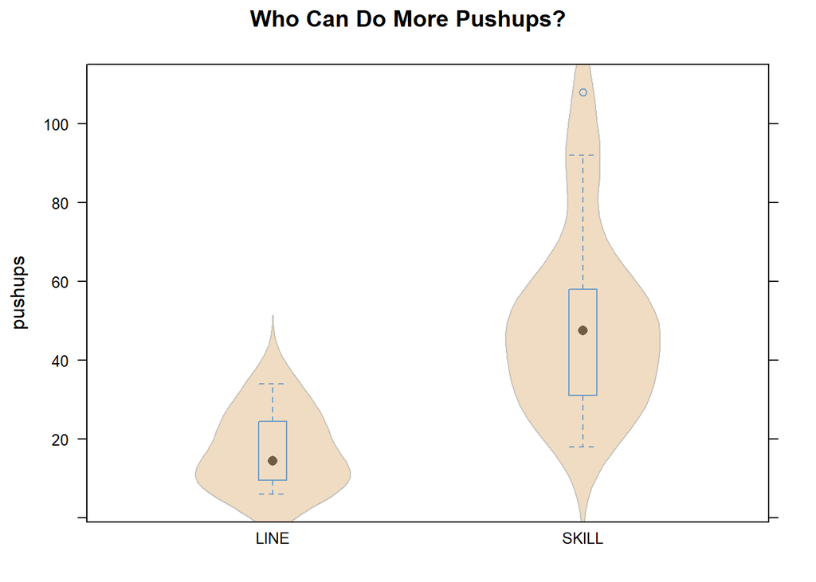

## Numerical Results

```
##   position min    Q1 median    Q3 max     mean        sd  n missing
## 1     LINE   6 10.25   14.5 24.25  34 17.12500  9.745878  8       0
## 2    SKILL  18 31.25   47.5 57.50 108 49.72727 23.036579 22       0
```

According to this we can determine that skill players can do more pushups than line players by determining the average.

# Inferential Results

```
##
##
## Inferential Procedures for the Difference of Two Means mu1-mu2:
##  (Welch's Approximation Used for Degrees of Freedom)
##   pushups grouped by position
##
##
## Descriptive Results:
##
##  group  mean     sd  n
##   LINE 17.12  9.746  8
##  SKILL 49.73 23.037 22
##
##
## Inferential Results:
##
## Estimate of mu1-mu2:  -32.6
## SE(x1.bar - x2.bar):  6
##
## 95% Confidence Interval for mu1-mu2:
##
##           lower.bound         upper.bound
##           -44.910660          -20.293886
```

```
##
##  Welch Two Sample t-test
##
## data:  pushups by position
## t = -5.4341, df = 27.079, p-value = 9.421e-06
## alternative hypothesis: true difference in means is not equal to 0
## 95 percent confidence interval:
##  -44.91068 -20.29387
## sample estimates:
##  mean in group LINE mean in group SKILL
##            17.12500            49.72727
```

Our Null Hypothesis shall be:

$H_0$: There is no relationship between the position of the players and the amount of pushups they can do.

Our Alternative Hypothesis shall be:

$H_0a$: There is a relationship between the position of the players and the amount of pushups they can do.

There is a 95% confidence interval that there is a difference between the two positions.

# Discussion and Conclusion

Based on all of these results we can conclude that there is a 95% confidence interval that there is a difference between the two positions. Skill players can do more pushups than line players. Even the average person with basic knowledge of football can conclude the same results. Line players are on the offense and defense and are required to be heavier with a higher body mass. Skill players run around trying to prevent the other team from scoring. They need to run around more than line players meaning, they need to be lighter to be faster. Based on this, a person can conclude that the lighter the body the more pushups a person can do.